# 금리리스크(Interest Rate Risk)

순이자수입(net interest income, NII)  
- 순이자마진(net inerest margin, NIM) 이라고도 함.

## 갭모형(GAP Model)

$$GAP = RSA - RSL$$
$$GAP\ ratio = \frac{RSA}{RSL}$$
금리민감형자산(rate sensitive asset, RSA)
금리민감형부채(rate sensitive liability, RSL)
순이자 수입 변화
$$\Delta NI = (RSA - RSL)\Delta i = (GAP)\Delta i$$

$\Delta NI$ = 순이자수입의 변화, $\Delta i$ = 이자율의 변화

#### 다기간 갭분석

| 1D | 20 | 30 | -10 |
| --- | --- | --- | --- |
| 3M | 30 | 40 | -10 |
| 6M | 70 | 85 | -15 |
| 12M | 90 | 70 | 20 |
| 5Y | 40 | 30 | 10 |
| 10Y | 5 | 5 | 0 |

누적갭(cumulative gap, CGAP)  
1년간의 누적갭을 구하면 아래와 같다.

$$CGAP = (-10억원) + (-10억원) + (-15억원) + 20억원 = -15억원$$

만일 1년이내에 평균이자율이 1% 상승한다면,
$$\Delta NI = (GAP)\Delta i = (-15억원) \times 0.01 = -1,500 만원$$

## 만기모형(Maturity Model)

금리 상승시에는 자산과 부채의 가치가 모두하락한다. 그러나 자산의 만기가 부채보다 길다면 자산의 가치 하락이 부채가치의 하락보다 상대적으로 크므로 자기자본 가치가 감소한다.

| 금리변동 | 만기구성 | 자산가치 | 부채가치 | 자기자본가치 |
| --- | --- | --- | --- | --- |
| 금리상승 | 자산만기 > 부채만기 | 대폭감소 | 소폭감소 | 감소 |
| 금리상승 | 자산만기 < 부채만기 | 소폭감소 | 대폭감소 | 증가 |
| 금리하락 | 자산만기 > 부채만기 | 대폭증가 | 소폭증가 | 증가 |
| 금리하락 | 자산만기 < 부채만기 | 소폭증가 | 대폭증가 | 감소 |

자산과 부채가의 만기차이가 클수록 자기자본 가치의 변동은 더욱 심하다. 따라서 이자율 변화에 따른 자기자본 가치의 변화정도를 측정하기 위하여 다음과 같은 만기갭(maturity gap)을 정의한다.
$$만기갭 = 자산의 만기 - 부채의 만기$$

만기갭을 실무적으로 사용할 때는 가중평균만기를 사용하게 된다.
$$M_i = W_{i1}M_{i1} + W_{i2}M_{i2} + \cdots + W_{in}M_{in}$$
$M_i$ = 금융기관 자산(부채)의 가중평균만기, i=A 또는 L)
$W_{ij}$ = j번째 자산(부채)의 총 시장가치 대비 해당 자산(부채)의 시가로 측정한 비중
$M_{ij}$ = j번째 자산(부채)의 만기, j = 1,2,…,n

금융기관의 자산과 부채의 만기를 일치시키는 전략은 금리리스크를 줄여주기는 하지만 그것을 완전히 없애주지는 못한다. 자산과 부채의 만기가 같다고 하더라도 금액이 불일치 하기 때문이다. 그러나 자산과 부채의 금액과 만기가 모두 일치한다 하더라도 현금흐름의 발생시점이 완전히 일치하지 않는 한, 금융기관은 여전히 금리리스크에 노출된다.

## 듀레이션 갭모형

듀레이션갭은 자산의 부채의 만기는 물론 각각으로부터 발생하는 현금흐름의 크기뿐만 아니라 더 나아가서 각 현금흐름의 발생시점까지도 고려하여 금리리스크를 측정하는 기법이다.

```r
source(file.path(getwd(),'risk3.R'))
get_duration(1000000, 0.1, 0.12, 2)$list
```

| i | n | pvif | p_n | pv | pv_n |
| --- | --- | --- | --- | --- | --- |
| 0.12 | 1 | 0.8928571 | 100000 | 89285.71 | 89285.71 |
| 0.12 | 2 | 0.7971939 | 100000 | 79719.39 | 159438.78 |
| 0.12 | 2 | 0.7971939 | 1000000 | 797193.88 | 1594387.76 |

```r
get_duration(1000000, 0.08, 0.08, 6)
```

```
## $d
## [1] 4.99271
##
## $md
## [1] 4.62288
##
## $pv
## [1] 1000000
##
## $list
##      i n      pvif     p_n        pv       pv_n
## 1 0.08 1 0.9259259   80000  74074.07   74074.07
## 2 0.08 2 0.8573388   80000  68587.11  137174.21
## 3 0.08 3 0.7938322   80000  63506.58  190519.74
## 4 0.08 4 0.7350299   80000  58802.39  235209.55
## 5 0.08 5 0.6805832   80000  54446.66  272233.28
## 6 0.08 6 0.6301696   80000  50413.57  302481.42
## 7 0.08 6 0.6301696 1000000 630169.63 3781017.76
```

듀레이션은 채권과 같은 고정금리부 자산의 가격변동성을 측정하는 지표가 된다. 듀레이션이 길다는 것은 이자율 변동에 대해 그 증권의 가격변동이 크다는 것을 의미하고, 그것이 짧다는 것은 변동성이 작다는 것을 의미한다.
듀레이션과 채권과 같은 고정금리부증권(또는 자산)의 가격변동성은 구체적으로 다음의 식과 같다.
$$\frac{\Delta P}{P} = -D(\frac{\Delta i}{1+i}) = -(\frac{D}{1+i})\Delta i = -D_m\Delta i$$
$P$ : 고정금리부자산의 현재가격
$\Delta P$ : 고정금리부자산의 현재가격의 변동
$i$ : 이자율
$\Delta i$ : 시장이자율의 변동
$D$ : 듀레이션
$D_m$ : 수정듀레이션
* 음(-)의 부호는 이자율과 자산가격이 반대로 변화하는 것을 의미한다. 쿠폰금리가 그대로일때, 시장이자율이 높아지면 현재가치는 떨어지고, 시장이자율이 낮아지면 현재가치는 높아진다.
액면가 100만원인 채권이자율(이표율, 쿠폰금리)가 8%이고 6년만기인 어떤채권의 만기수익율은 8%라고 한다. 현재가치는 아래와 같다.

```r
get_duration(1000000, 0.08, 0.08, 6)$pv
```

```
## [1] 1000000
```

만약 만기수익률(시장이자율) 8.01% 로 상승한다면, 채권의 가격은 아래와 같이 변한다.

```r
get_duration(1000000, 0.08, 0.0801, 6)$pv
```

```
## [1] 999537.9
```

수정듀레이션 값을 알면, 이자율의 변화량 및 액면가를 곱하여 아래와 같이도 구할 수 있다.

```r
1000000 - get_duration(1000000, 0.08, 0.08, 6)$md * 0.0001 * 1000000
```

```
## [1] 999537.7
```

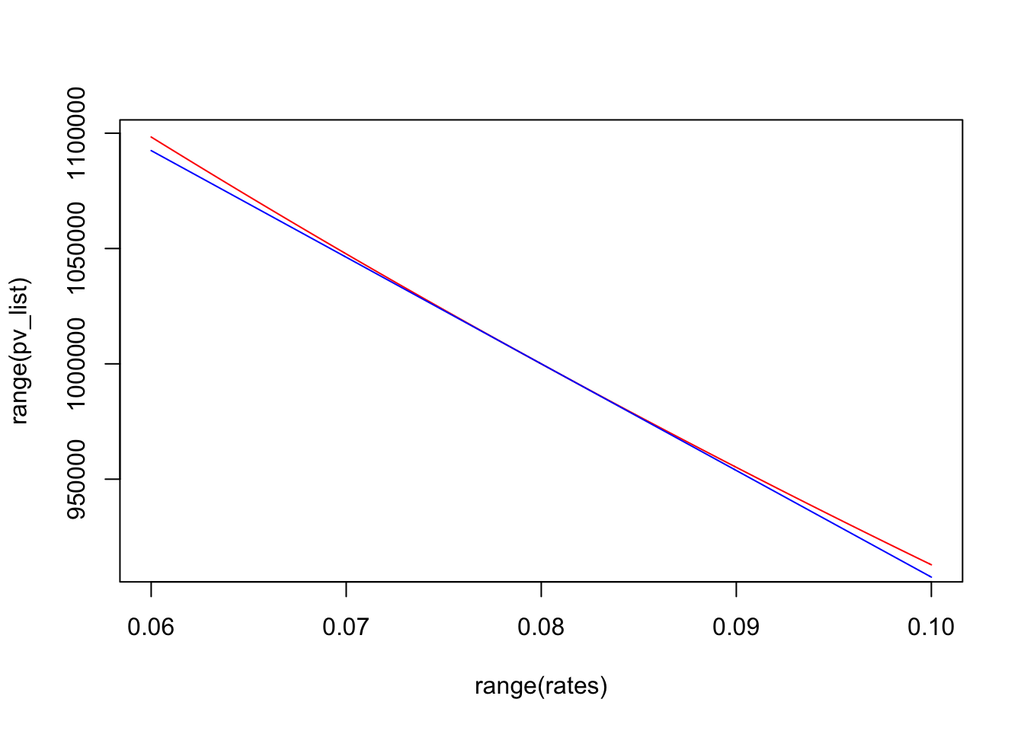

```r
rates <- seq(0.06, 0.1,by = 0.0001)
md <- get_duration(1000000, 0.08, 0.08, 6)$md
pv_list <- c()
pv_list2 <- c()
for(r in rates){
    pv_list <- c(pv_list, sum(get_bond_pv(1000000, 0.08, r,6)$pv))
    pv_list2 <- c(pv_list2, 1000000 - md * (r - 0.08) * 1000000)
}

plot(range(rates), range(pv_list), type = "n")
lines(x = rates, y = pv_list, col = "red")
lines(x= rates, y= pv_list2, col = "blue")
```